# Lecture 3: Hypothesis testing, and model fitting

*`@prepared by Hoang Duc Thuong, Department of Space and Applications, USTH.`* hoang-duc.thuong@usth.edu.vn

In this class, We will use $\chi^2$ statistic as a hypotheisis testing model and parameters fitting to find the best-fit model.

$$\chi^2 = \sum_{i=1}^N \left( \frac{x_i - \mu_i}{\sigma_i} \right)^2$$

```python
import matplotlib
params = {
	'axes.labelsize': 30,
	'font.size': 28,
	'legend.fontsize': 26,
	'xtick.labelsize': 30,
	'ytick.labelsize': 30,
	'lines.linewidth': 4,
	'text.usetex': False,
	# 'figure.autolayout': True,
	'ytick.right': True,
	'xtick.top': True,

	'figure.figsize': [10, 8], # instead of 4.5, 4.5
	'axes.linewidth': 2.5,

	'xtick.major.size': 26,
	'ytick.major.size': 26,
	'xtick.minor.size': 26,
	'ytick.minor.size': 26,

	'xtick.major.width': 2.5,
	'ytick.major.width': 2.5,
	'xtick.minor.width': 2.5,
	'ytick.minor.width': 2.5,

	'xtick.major.pad': 10,
	'ytick.major.pad': 10,
	#'xtick.minor.pad': 14,
	#'ytick.minor.pad': 14,

	'xtick.direction': 'in',
	'ytick.direction': 'in',
   }
matplotlib.rcParams.update(params)
```

```python
import pandas as pd
from scipy import stats
import numpy as np
import matplotlib.pyplot as plt

direc = '/Users/USTH/TEACHING/SA2.7DataAnalysisandVisualization/'
# Change this to be your!
```

# Hypothesis testing using $\chi^2$

$\chi^2$ probability distribution:

$$P(\chi^2) \propto \left( \chi^2 \right)^{\frac{\nu}{2}-1} e^{-\chi^2/2}. $$

Where $\nu$ is the number of **degrees of freedom**.

## p-value

- If the p-value is not low, the data are consistent with the model, which is “ruled in”.
- If the p-value is low, the model is “ruled out”

To use $\chi^2$ as a hypothesis test, we compute $\chi^2$ for a given dataset and model. We then ask the question: **if the model is correct, what is the probability that this value of $\chi^2$, or a larger one, could arise by chance?** This probability is called the $p$-value and may be calculated from $P(\chi^2)$ by integrating the area under the curve at values greater than some value of $\chi^2$.

```
dx 0.16
p-value1 = 0.011164780271550323
p-value2 = 0.012596739762499502
i 125
i 406
```

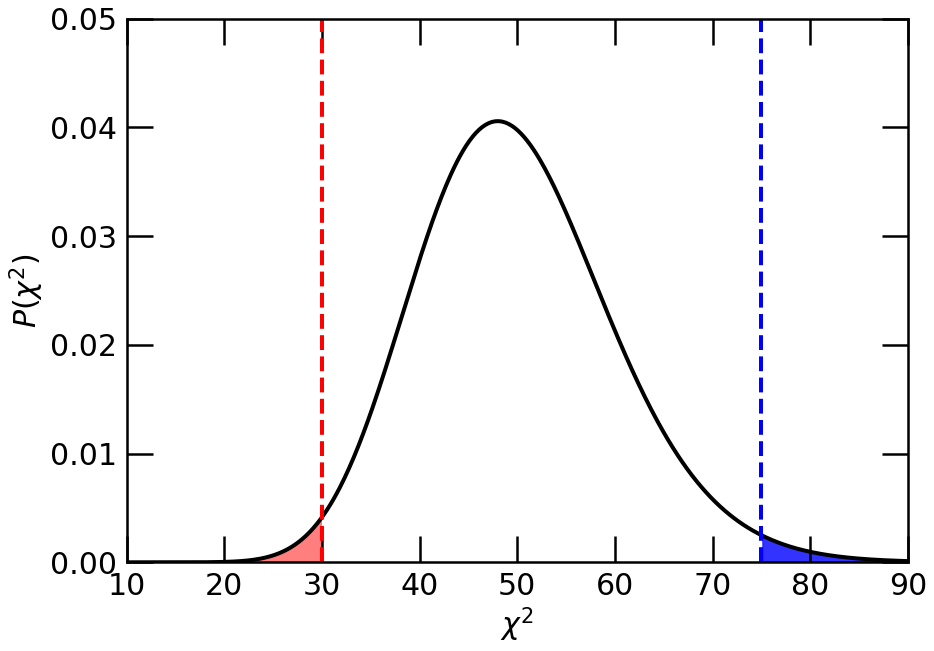

```python
nu = 50 # number of degrees of freedom
chisq1 = 30   # 1st value of chi-squared to test
chisq2 = 75 # 2nd value of chi-squared to test

# Range of values for chi-squared
xmin,xmax,nx = 10,90.,500   # change the nx to have a better resolution.
x_chi = np.linspace(xmin,xmax,nx)
dx = (xmax-xmin)/nx  ; print('dx',dx)    # bin size
ymin,ymax = 0.,0.05

## Calculate p value
dof = nu                                # number of degrees of freedom (data points minus fitted parameters)
p_value1 = 1 - stats.chi2.sf(chisq1,dof) # probability of chi-squared to exceed the value we've found
                                         # 1 - : Becasue The p value is calculated from intergrating from are that greater than value of chi-square
p_value2 = stats.chi2.sf(chisq2,dof)
print('p-value1 =', p_value1)
print('p-value2 =', p_value2)

# Determine chi-squared probability distribution
y_chi = stats.chi2.pdf(x_chi,nu)

fig = plt.figure(figsize=(14, 10) )
plt.plot(x_chi,y_chi,color='black')


# Find 1st chi-squared test value in array, and shade area under the curve at greater values
plt.plot([chisq1,chisq1],[ymin,ymax],color='red',linestyle='dashed')
i = int((chisq1-xmin)/dx) ;print('i',i)
plt.fill_between(x_chi[:i], np.zeros_like(x_chi[:i]), y_chi[:i], color='red',alpha=0.5)
# The parameters are actualy x, y1, y2, Here:
# x is the a axis values.
# y1 = 0 is a zero values for all x axis
# y2 = y_chi values


# Find 2nd chi-squared test value in array, and shade area under the curve at greater values
plt.plot([chisq2, chisq2],[ymin,ymax],color='blue',linestyle='dashed')

i = int((chisq2-xmin)/dx) ; print('i',i)
plt.fill_between(x_chi[i:], np.zeros_like(x_chi[i:]), y_chi[i:], color='blue', alpha=0.8)


# Complete plot
plt.xlabel(r'$\chi^2$')
plt.ylabel(r'$P(\chi^2)$')
plt.xlim(xmin,xmax)
plt.ylim(ymin,ymax)

plt.savefig('ChiSquare_two_tail.png',dpi=300)
```

**Example:**

```
p-value1 = 0.2426404373497379
p-value2 = 0.0097408242493361
index location value :  350
```

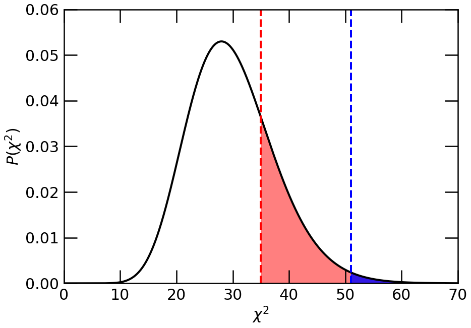

```python
# Plot chi-squared probability distribution
# Indicate areas under the curve at values of chi-squared greater than a couple of test values

nu = 30     # number of degrees of freedom
chisq1 = 35 # 1st value of chi-squared to test
chisq2 = 51 # 2nd value of chi-squared to test

# Range of values for chi-squared
xmin,xmax,nx = 0.,70.,701
x_chi = np.linspace(xmin,xmax,nx)
dx = (xmax-xmin)/nx
ymin,ymax = 0.,0.06

## Calculate p value
dof = nu                             # number of degrees of freedom (data points minus fitted parameters)
p_value1 = stats.chi2.sf(chisq1,dof) # probability of chi-squared to exceed the value we've found
p_value2 = stats.chi2.sf(chisq2,dof)
print('p-value1 =', p_value1)
print('p-value2 =', p_value2)


# Determine chi-squared probability distribution
y_chi = stats.chi2.pdf(x_chi,nu)

fig = plt.figure(figsize=(14, 10) )
plt.plot(x_chi,y_chi,color='black')

# Find 1st chi-squared test value in array, and shade area under the curve at greater values
plt.plot([chisq1,chisq1],[ymin,ymax],color='red',linestyle='dashed')
i = int((chisq1-xmin)/dx) ; print('index location value : ', i) # index
plt.fill_between(x_chi[i:], np.zeros_like(x_chi[i:]), y_chi[i:], color='red',alpha=0.5)
#plt.fill_between(x_chi[i:], np.ones_like(x_chi[i:])*0.01, y_chi[i:], color='red',alpha=0.5)
#np.one_like(x_chi[i:])*0.01

# Find 2nd chi-squared test value in array, and shade area under the curve at greater values
plt.plot([chisq2,chisq2],[ymin,ymax],color='blue',linestyle='dashed')
i = int((chisq2-xmin)/dx)
plt.fill_between(x_chi[i:], np.zeros_like(x_chi[i:]), y_chi[i:], color='blue', alpha=0.8)


# Complete plot
plt.xlabel(r'$\chi^2$')
plt.ylabel(r'$P(\chi^2)$')
plt.xlim(xmin,xmax)
plt.ylim(ymin,ymax)

plt.savefig('ChiSquare_example.png',dpi=300)
```

```python
#plt.fill_between?
```

The resulting $p$-values in these cases are:

```python
nu = 30 # number of degrees of freedom
chisq1 = 35 # 1st value of chi-squared to test
chisq2 = 51 # 2nd value of chi-squared to test

p1 = stats.chi2.sf(chisq1,nu) # probability of chi-squared exceeding the 1st test value
p2 = stats.chi2.sf(chisq2,nu) # probability of chi-squared exceeding the 2nd test value

print('p-value for chi2 =',chisq1,'and nu =',nu,'is p =',p1)
print('p-value for chi2 =',chisq2,'and nu =',nu,'is p =',p2)
```

```
p-value for chi2 = 35 and nu = 30 is p = 0.2426404373497379
p-value for chi2 = 51 and nu = 30 is p = 0.0097408242493361
```

# Parameter estimation using $\chi^2$

This process is described in the following worked example. Consider the following example dataset containing $N=10$ points:

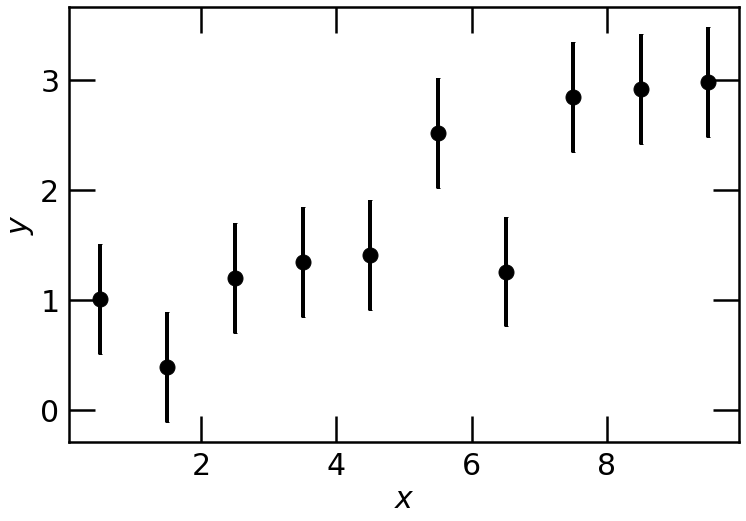

```python
data = np.loadtxt(direc+'/data/straightline.dat')

x,y,yerr = data[:,0],data[:,1],data[:,2]
n = len(x)

fig = plt.figure(figsize=(12, 8) )
plt.plot(x,y,marker='o',markersize=15,color='black',linestyle='None')
plt.errorbar(x,y,yerr=yerr,color='black',capsize=2.,linestyle='None')
plt.xlabel(r'$x$')
plt.ylabel(r'$y$')

plt.savefig('Straight_line.png',dpi=300)
```

```python
print('x', x, '\ny', y)
```

```
x [0.5 1.5 2.5 3.5 4.5 5.5 6.5 7.5 8.5 9.5]
y [1.01 0.39 1.2  1.35 1.41 2.52 1.26 2.85 2.92 2.99]
```

## y = b

Could these points be fit by a constant $y = b$, and if so what is the best-fitting value of $b$? We can answer that question by minimizing the $\chi^2$ statistic:

```python
from scipy.optimize import curve_fit

def f_cst(x, B): # this is your 'straight line' y=B
    y=B
    return y

popt_cst, pcov_cst = curve_fit(f_cst, x, y)        # your data x, y to fit
```

```python
popt_cst
```

```
array([1.79])
```

```python
f_cst(x,*popt_cst)
```

```
1.7900000000017233
```

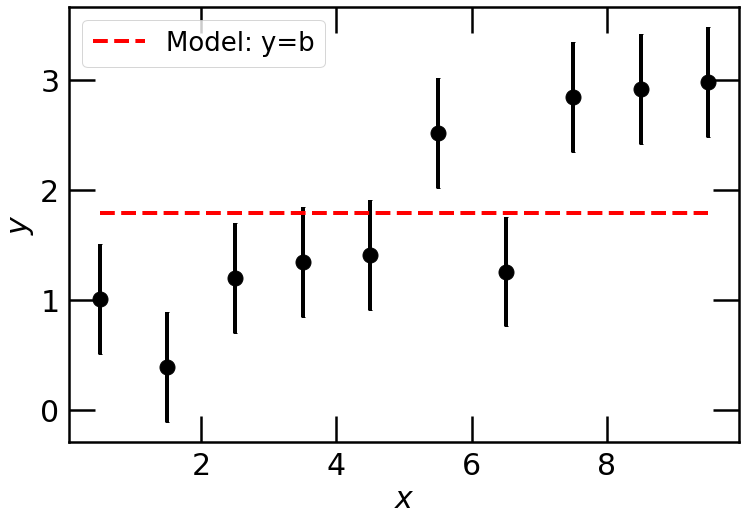

```python
horiz_line_data = np.array([popt_cst for i in range(len(x))])

fig = plt.figure(figsize=(12, 8) )
plt.plot(x,y,marker='o',markersize=15,color='black',linestyle='None')
plt.errorbar(x,y,yerr=yerr,color='black',capsize=2.,linestyle='None')
plt.plot(x, horiz_line_data, 'r--', label ='Model: y=b')

plt.xlabel(r'$x$')
plt.ylabel(r'$y$')

plt.legend()

plt.savefig('Straight_line_const.png',dpi=300)
```

```python
# Function which evaluates the chi-squared value of a model y=b for the (x,y) dataset
def chisqstraightline1(p,x,y,yerr):
  b = p[0]
  return np.sum( ((y - b)/yerr)**2 )  ## (data - model)/sigma_error


# Find the best-fitting model y=b to the (x,y) dataset by minimising chi-squared
from scipy.optimize import minimize


p0 = [1.] # initial guess of the value of b (result should not depend on this)
result1 = minimize(chisqstraightline1,p0,args=(x,y,yerr)) # perform the minimisation

b1 = result1['x'][0] # best-fitting value of b

minchisq1 = result1['fun'] # chi-squared value corresponding to the best fit
dof1 = n-1 # number of degrees of freedom (data points minus fitted parameters)

print('Best-fitting value of b =', b1)
print('Minimum chi-squared =', minchisq1)
print('Number of degrees of freedom =', dof1)
```

```
Best-fitting value of b = 1.7899999897904915
Minimum chi-squared = 31.635200000000005
Number of degrees of freedom = 9
```

```python
result1
```

```
      fun: 31.635200000000005
 hess_inv: array([[0.0125]])
      jac: array([0.])
  message: 'Optimization terminated successfully.'
     nfev: 6
      nit: 2
     njev: 3
   status: 0
  success: True
        x: array([1.78999999])
```

```
p-value1 = 0.00023343879633546733
```

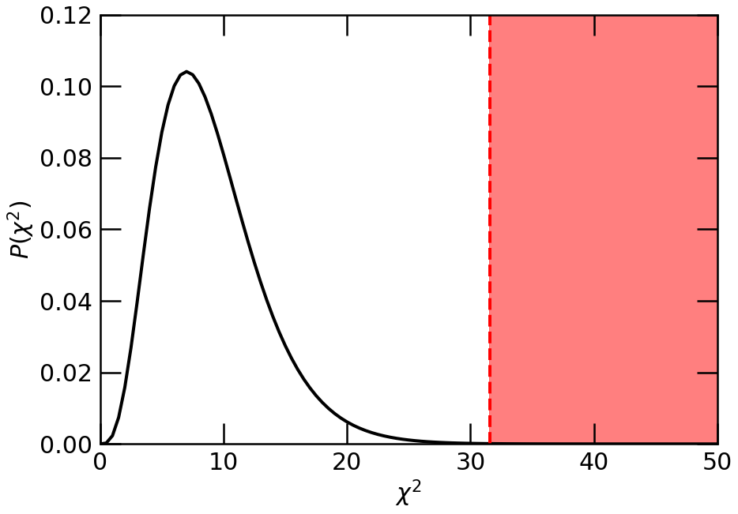

```python
nu = 10-1 # number of degrees of freedom = 10 data point - 1 (parameter)
chisq1 = 31.6 # 1st value of chi-squared to test
chisq2 = 51 # 2nd value of chi-squared to test


# Range of values for chi-squared
xmin,xmax,nx = 0.,50,101
x_chi = np.linspace(xmin,xmax,nx)
dx = (xmax-xmin)/nx
ymin,ymax = 0.,0.12

## Calculate p value
dof = nu                             # number of degrees of freedom (data points minus fitted parameters)
p_value1 = stats.chi2.sf(chisq1,dof) # probability of chi-squared to exceed the value we've found
print('p-value1 =', p_value1)


# Determine chi-squared probability distribution
y_chi = stats.chi2.pdf(x_chi,nu)

fig = plt.figure(figsize=(14, 10) )
plt.plot(x_chi,y_chi,color='black')

# Find 1st chi-squared test value in array, and shade area under the curve at greater values
plt.plot([chisq1,chisq1],[ymin,ymax],color='red',linestyle='dashed')
i = int((chisq1-xmin)/dx) ; # print(i)
#plt.fill_between(x_chi[i:], np.zeros_like(x_chi[i:]),y_chi[i:],color='red',alpha=0.5)
plt.fill_between(x_chi[i:], x_chi[xmax],color='red',alpha=0.5)

#plt.axvspan(x_chi[i:], x_chi[i:xmax])
#print(np.zeros_like(x_chi[i:]),y_chi[i:])

# Find 2nd chi-squared test value in array, and shade area under the curve at greater values
plt.plot([chisq2,chisq2],[ymin,ymax],color='green',linestyle='dashed')
i = int((chisq2-xmin)/dx)
plt.fill_between(x_chi[i:], np.zeros_like(x_chi[i:]), y_chi[i:], color='green', alpha=0.8)


# Complete plot
plt.xlabel(r'$\chi^2$')
plt.ylabel(r'$P(\chi^2)$')
plt.xlim(xmin,xmax)
plt.ylim(ymin,ymax)

plt.savefig('Straight_line_const_chisquare.png',dpi=300)
```

# y = a*x

```python
def f_slope(x, A): # this is your 'straight line' y=Bx
    y=A*x
    return y

popt_slope, pcov_slope = curve_fit(f_slope, x, y)  # your data x, y to fit
```

```python
popt_slope
```

```
array([0.33627068])
```

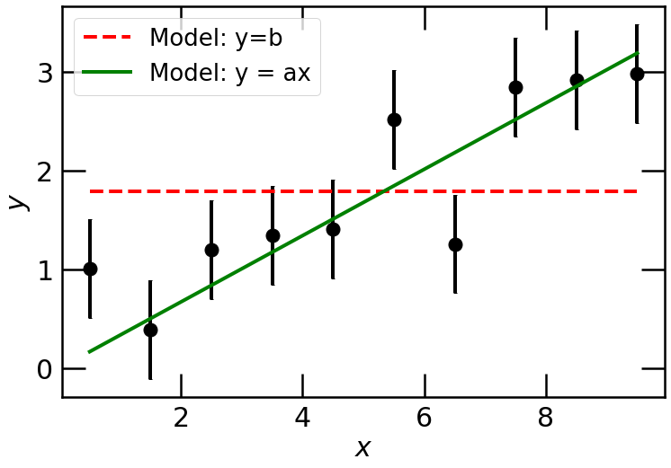

```python
horiz_line_data = np.array([popt_cst for i in range(len(x))])

fig = plt.figure(figsize=(12, 8) )
plt.plot(x,y,marker='o',markersize=15,color='black',linestyle='None')
plt.errorbar(x,y,yerr=yerr,color='black',capsize=2.,linestyle='None')
plt.plot(x, horiz_line_data, 'r--', label ='Model: y=b')

plt.plot(x, f_slope(x,*popt_slope), color='green',linestyle='-', label='Model: y = ax')

plt.xlabel(r'$x$')
plt.ylabel(r'$y$')

plt.legend()

plt.savefig('Straight_line_slope.png',dpi=300)
```

```python
# Function which evaluates the chi-squared value of a model y=a*x+b for the (x,y) dataset
def chisqstraightline2(p,x,y,yerr):
  a = p[0]
  return np.sum(  ( (y - a*x ) /yerr)**2 )    ## (data - model)/sigma_error


# Find the best fitting model y=a*x to the (x,y) dataset by minimising chi-squared
p0 = [0.2] # initial guess of the values of a (result should not depend on this)

result2 = minimize(chisqstraightline2,p0,args=(x,y,yerr)) # perform the minimisation
a2 = result2['x'] # best-fitting values of a

minchisq2 = result2['fun']          # chi-squared value corresponding to the best fit
dof2 = n-1                        # number of degrees of freedom (data points minus fitted parameters)
p2 = stats.chi2.sf(minchisq2,dof2) # probability of chi-squared to exceed the value we've found

print('Best-fitting value of a =', a2)
print(r'Minimum chi-squared $\chi^2$ =', minchisq2)
print('Number of degrees of freedom =', dof2)
print('p-value =', p2)
```

```
Best-fitting value of a = [0.33627067]
Minimum chi-squared $\chi^2$ = 9.405502556390994
Number of degrees of freedom = 9
p-value = 0.4007152300565288
```

```python
result2
```

```
      fun: 9.405502556390994
 hess_inv: array([[0.00037594]])
      jac: array([1.02519989e-05])
  message: 'Desired error not necessarily achieved due to precision loss.'
     nfev: 87
      nit: 1
     njev: 38
   status: 2
  success: False
        x: array([0.33627067])
```

```
p-value1 = 0.00023343879633546733
p-value2 = 0.40119928658025733
i 94
```

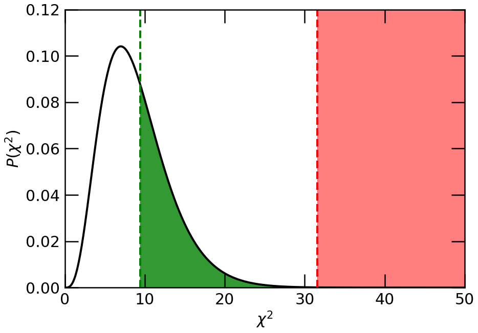

```python
nu = 10-1 # number of degrees of freedom = 10 data point - 1 (parameter)
chisq1 = 31.6 # 1st value of chi-squared to test
chisq2 = 9.4 # 2nd value of chi-squared to test


# Range of values for chi-squared
xmin,xmax,nx = 0.,50,501
x_chi = np.linspace(xmin,xmax,nx)
dx = (xmax-xmin)/nx
ymin,ymax = 0.,0.12

## Calculate p value
dof = nu                             # number of degrees of freedom (data points minus fitted parameters)
p_value1 = stats.chi2.sf(chisq1,dof) # probability of chi-squared to exceed the value we've found
p_value2 = stats.chi2.sf(chisq2,dof)
print('p-value1 =', p_value1)
print('p-value2 =', p_value2)


# Determine chi-squared probability distribution
y_chi = stats.chi2.pdf(x_chi,nu)

fig = plt.figure(figsize=(14, 10) )
plt.plot(x_chi,y_chi,color='black')

# Find 1st chi-squared test value in array, and shade area under the curve at greater values
plt.plot([chisq1,chisq1],[ymin,ymax],color='red',linestyle='dashed')
i = int((chisq1-xmin)/dx) ; # print(i)
#plt.fill_between(x_chi[i:], np.zeros_like(x_chi[i:]),y_chi[i:],color='red',alpha=0.5)
plt.fill_between(x_chi[i:], x_chi[xmax],color='red',alpha=0.5)

#plt.axvspan(x_chi[i:], x_chi[i:xmax])
#print(np.zeros_like(x_chi[i:]),y_chi[i:])

# Find 2nd chi-squared test value in array, and shade area under the curve at greater values
plt.plot([chisq2, chisq2],[ymin,ymax],color='green',linestyle='dashed')
i = int((chisq2-xmin)/dx) ; print('i',i)
plt.fill_between(x_chi[i:], np.zeros_like(x_chi[i:]), y_chi[i:], color='green', alpha=0.8)


# Complete plot
plt.xlabel(r'$\chi^2$')
plt.ylabel(r'$P(\chi^2)$')
plt.xlim(xmin,xmax)
plt.ylim(ymin,ymax)

plt.savefig('Straight_line_slope_chisquare.png',dpi=300)
```

# y=a*x + b

Instead, could these points be fit by a straight line $y = ax + b$? Minimize $\chi^2$ as before:

```python
from scipy.optimize import curve_fit

def f_linear(x, a, b):       # this is your 'straight line' y=f(x)
    return a*x + b

popt, pcov = curve_fit(f_linear, x, y)   # your data x, y to fit
```

```python
popt
```

```
array([0.27042424, 0.43787879])
```

```python
np.sqrt(pcov)
```

```
array([[0.05330921,        nan],
       [       nan, 0.30739588]])
```

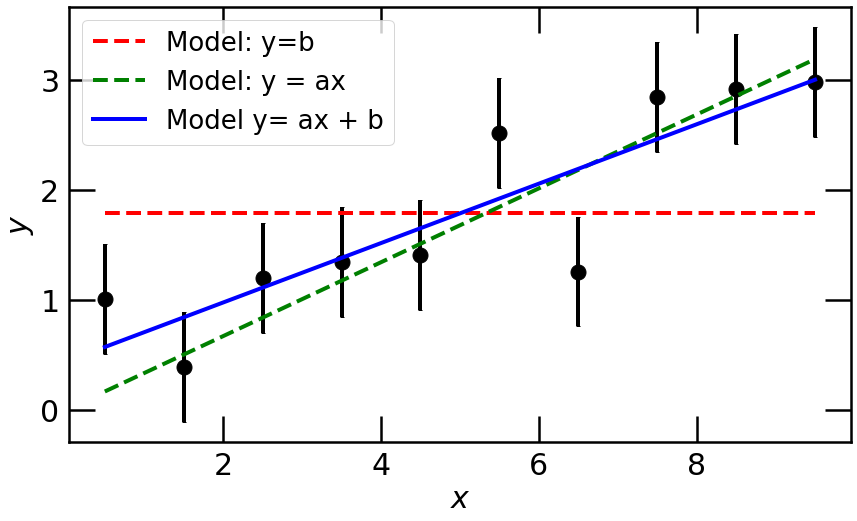

```python
fig = plt.figure(figsize=(14, 8) )
plt.plot(x,y,marker='o',markersize=15,color='black',linestyle='None')
plt.errorbar(x,y,yerr=yerr,color='black',capsize=2.,linestyle='None')

plt.plot(x, horiz_line_data, 'r--', label ='Model: y=b')
plt.plot(x, f_slope(x,*popt_slope), color='green',linestyle='--', label='Model: y = ax')
plt.plot(x, f_linear(x,*popt),color='blue',linestyle='-', label='Model y= ax + b')

plt.xlabel(r'$x$')
plt.ylabel(r'$y$')
plt.legend()
#plt.xlim(1,6)

plt.savefig('Straight_line_fitted.png',dpi=300)
```

```python
# Function which evaluates the chi-squared value of a model y=a*x+b for the (x,y) dataset
def chisqstraightline3(p,x,y,yerr):
  a,b = p[0],p[1]
  return np.sum( ( (y - (a*x + b) )/yerr)**2 )    ## (data - model)/sigma_error


# Find the best fitting model y=a*x+b to the (x,y) dataset by minimising chi-squared
p0 = [0.2, 1.] # initial guess of the values of a,b (result should not depend on this)

result = minimize(chisqstraightline3,p0,args=(x,y,yerr)) # perform the minimisation
a3, b3 = result['x'] # best-fitting values of a,b

minchisq3 = result['fun']          # chi-squared value corresponding to the best fit
dof3 = n-2                         # number of degrees of freedom (data points minus fitted parameters)
p3 = stats.chi2.sf(minchisq3,dof3) # probability of chi-squared to exceed the value we've found

print('Best-fitting value of a =', a3)
print('Best-fitting value of b =', b3)
print(r'Minimum chi-squared $\chi^2$ =', minchisq3)
print('Number of degrees of freedom =', dof3)
print('p-value =', p3)
```

```
Best-fitting value of a = 0.27042421678017053
Best-fitting value of b = 0.4378789090155025
Minimum chi-squared $\chi^2$ = 7.502540606060829
Number of degrees of freedom = 8
p-value = 0.48350484463274246
```

```python
result
```

```
      fun: 7.502540606060829
 hess_inv: array([[ 0.00151515, -0.00757576],
       [-0.00757576,  0.05037879]])
      jac: array([5.96046448e-08, 0.00000000e+00])
  message: 'Optimization terminated successfully.'
     nfev: 21
      nit: 5
     njev: 7
   status: 0
  success: True
        x: array([0.27042422, 0.43787891])
```

```
p-value1 = 0.00010982390053170775
p-value2 = 0.3096835741561239
p-value3 = 0.4837673815536875
i 94
i 75
```

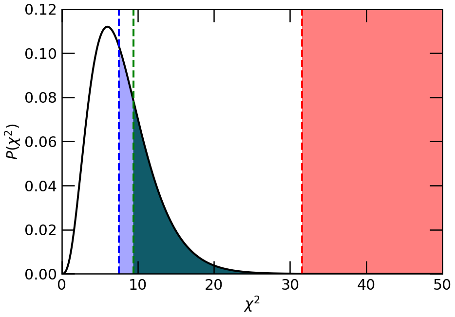

```python
nu = 10-2 # number of degrees of freedom = 10 data point - 1 (parameter)
chisq1 = 31.6 # 1st value of chi-squared to test
chisq2 = 9.4 # 2nd value of chi-squared to test
chisq3 = 7.5

# Range of values for chi-squared
xmin,xmax,nx = 0.,50,501
x_chi = np.linspace(xmin,xmax,nx)
dx = (xmax-xmin)/nx
ymin,ymax = 0.,0.12

## Calculate p value
dof = nu                             # number of degrees of freedom (data points minus fitted parameters)
p_value1 = stats.chi2.sf(chisq1,dof) # probability of chi-squared to exceed the value we've found
p_value2 = stats.chi2.sf(chisq2,dof)
p_value3 = stats.chi2.sf(chisq3,dof)
print('p-value1 =', p_value1)
print('p-value2 =', p_value2)
print('p-value3 =', p_value3)


# Determine chi-squared probability distribution
y_chi = stats.chi2.pdf(x_chi,nu)


# plot
fig = plt.figure(figsize=(14, 10) )
plt.plot(x_chi,y_chi,color='black')

# Find 1st chi-squared test value in array, and shade area under the curve at greater values
plt.plot([chisq1,chisq1],[ymin,ymax],color='red',linestyle='dashed')
i = int((chisq1-xmin)/dx) ; # print(i)
#plt.fill_between(x_chi[i:], np.zeros_like(x_chi[i:]),y_chi[i:],color='red',alpha=0.5)
plt.fill_between(x_chi[i:], x_chi[xmax], color='red', alpha=0.5)

#plt.axvspan(x_chi[i:], x_chi[i:xmax])
#print(np.zeros_like(x_chi[i:]),y_chi[i:])

# Find 2nd chi-squared test value in array, and shade area under the curve at greater values
plt.plot([chisq2, chisq2],[ymin,ymax],color='green',linestyle='dashed')
i = int((chisq2-xmin)/dx) ; print('i',i)
plt.fill_between(x_chi[i:], np.zeros_like(x_chi[i:]), y_chi[i:], color='green', alpha=0.9)

# Find 3rd chi-squared test value in array, and shade area under the curve at greater values
plt.plot([chisq3, chisq3],[ymin,ymax],color='blue',linestyle='dashed')
i = int((chisq3-xmin)/dx) ; print('i',i)
plt.fill_between(x_chi[i:], np.zeros_like(x_chi[i:]), y_chi[i:], color='blue', alpha=0.35)


# Complete plot
plt.xlabel(r'$\chi^2$')
plt.ylabel(r'$P(\chi^2)$')
plt.xlim(xmin,xmax)
plt.ylim(ymin,ymax)

plt.savefig('Straight_line_line_chisquare.png',dpi=300)
```

## Activity:

Fit the data with equation $y=ax+b$ and estimate $\chi^2$ without using `scipy` library.

| x | 1.0 | 2.0 | 3.0 | 4.0 | 5.0 |
| --- | --- | --- | --- | --- | --- |
| y | 2.2 | 2.9 | 4.3 | 5.2 | 6.3 |
| $$\sigma$$ | 0.2 | 0.4 | 0.3 | 0.1 | 0.35 |

## Activity

The Hubble–Lemaître law, $$v = H_0D$$

where v is the velocity, D is the distance and $H_0$ is the Hubble constant.

Recall the Hubble data of Lemaitre and Hubble measurements.

- Fit the linear equation (y=ax and y=ax+b).
- Estimate $\chi^2$ value.
- Make a 2D confidence regions for 2 parameters in case of the model y =ax+b.

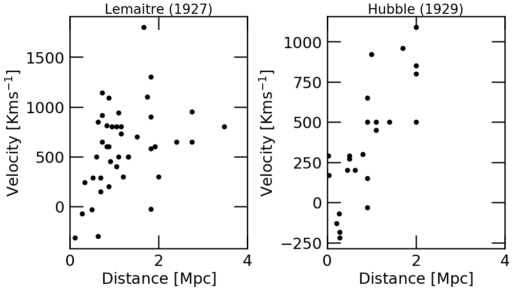

```python
data_Hubble = np.loadtxt(direc+'/data/hubble.dat')
data_Lemaitre = np.loadtxt(direc+'/data/lemaitre.dat')

Distance_Hubble,Velocity_Hubble = data_Hubble[:,0],data_Hubble[:,1]
Distance_Lemaitre,Velocity_Lemaitre = data_Lemaitre[:,0],data_Lemaitre[:,1]


#fig, ax = plt.subplots(figsize=(10, 7))
fig, axes = plt.subplots(1, 2, figsize=(14, 8))

axes[0].scatter(Distance_Lemaitre,Velocity_Lemaitre,marker='o',s=80, color='black')
axes[0].set_xlabel(r'Distance $\rm [Mpc]$')
axes[0].set_ylabel(r'Velocity $\rm [Kms^{-1}]$')
axes[0].set_xlim(0,4)
axes[0].set_title('Lemaitre (1927)', fontsize=26)


axes[1].scatter(Distance_Hubble,Velocity_Hubble,marker='o',s=80, color='black')
axes[1].set_xlabel(r'Distance $\rm [Mpc]$')
axes[1].set_ylabel(r'Velocity $\rm [Kms^{-1}]$')
axes[1].set_xlim(0,4)
axes[1].set_title('Hubble (1929)', fontsize=26)

plt.tight_layout()

plt.savefig('Hubble_constant.png',dpi=300)
```

```python
Distance_Lemaitre
```

```
array([0.63, 0.11, 2.75, 1.82, 1.66, 0.28, 1.82, 1.2 , 0.72, 3.47, 1.51,
       1.05, 0.83, 0.5 , 0.69, 0.87, 1.1 , 0.83, 1.91, 1.15, 1.05, 0.72,
       1.15, 2.75, 2.  , 0.6 , 1.1 , 0.87, 0.63, 0.95, 1.82, 1.74, 0.72,
       0.87, 0.52, 0.69, 1.82, 0.91, 0.33, 1.32, 2.4 , 1.32])
```

```python
Velocity_Lemaitre
```

```
array([-300., -315.,  650.,  -25., 1800.,  -70., 1300.,  300.,  916.,
        800.,  700.,  400.,  600.,  -30.,  290.,  600.,  940.,  812.,
        600.,  730.,  800.,  650.,  800.,  950.,  300.,  500.,  500.,
        200.,  850.,  800.,  580., 1100., 1140., 1090.,  290.,  150.,
        900.,  450.,  240.,  500.,  650.,  500.])
```

## Join confident region

We know that today, the dark energy is domonated in our Universe compare to matter. The result is tested by many observational data of experiments.

[figure not shown]

(*Planck result*)

**Example:** The join analytical measurements of galaxy clusters, supernovae, and Cosmic microwaves background (CMB) to estimate the dark matter parameter ($\Omega_{m} \approx 0.3$), and the dark energy ($\Omega_{\Lambda} \approx 0.7$) in the universe.

[figure not shown]

A model typically contains free parameters. How do we determine the most likely values of these parameters and their error ranges?

- Assuming that we are fitting a model with 2 free parameters (a,b).
- The “best-fitting” values of (a,b) are found by minimizing the $\chi^2$ statistic.
- The joint error distribution of parameters (a,b) can be found by calculating the values of $\chi^2$ over a grid of (a,b) and enclosing a particular region $\chi^2 < \chi^2_{min} + \Delta \chi^2$
- Plot contour 2D $\chi^2 < \chi^2_{min} + \Delta \chi^2$

```python
# Function which evaluates the chi-squared value of a model y=a*x+b for the (x,y) dataset
def chisqstraightline4(p,x,y,yerr):
  a,b = p[0],p[1]
  return np.sum( ( (y - (a*x + b) )/yerr)**2 )    ## (data - model)/sigma_error
```

```
Minimum chi-squared = 7.5028281250000015
Best-fitting value of a = 0.27125
Best-fitting value of b = 0.4325
confident region [ 7.50282813  9.80282813 13.67282813 19.30282813]
```

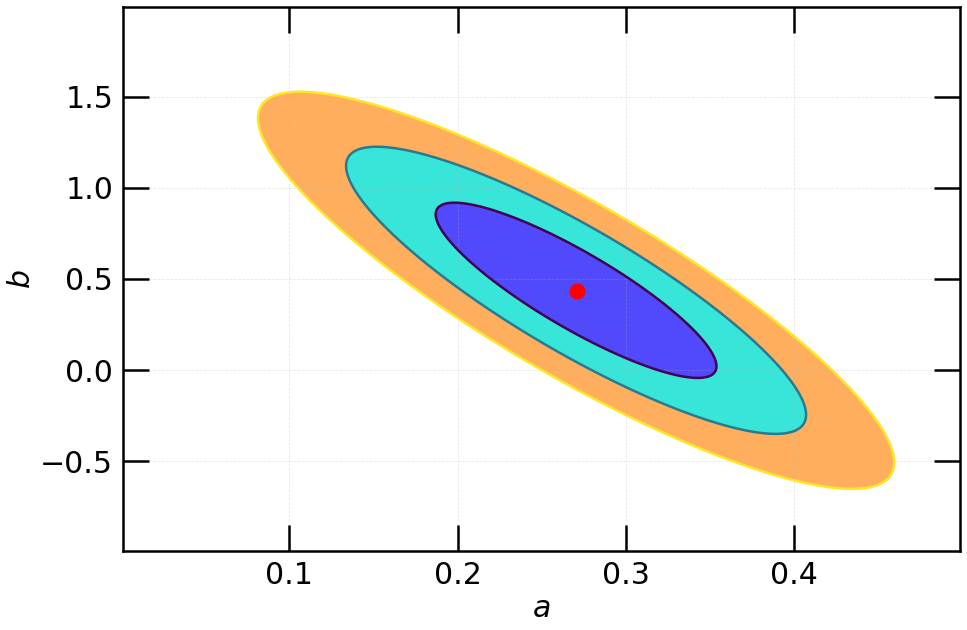

```python
from matplotlib import cm

# Use the chi-squared method to create joint confidence intervals
# of model parameters a,b fit to a dataset
# Create grid of values of the model parameters a,b

amin,amax,na = 0., 0.5, 200
bmin,bmax,nb = -1., 2., 200

da,db = (amax-amin)/na,(bmax-bmin)/nb

alst = np.linspace(amin+0.5*da,amax-0.5*da,na)  ## shift  1 step 0.5*da
blst = np.linspace(bmin+0.5*db,bmax-0.5*db,nb)
#print('alst', alst, '\n blst',blst)

# Evaluate the chi-squared value at each grid point
# (i.e. for each set of model parameters)
# (Note that we are not performing a *minimisation*
# for each set of model parameters, just an evaluation)


chisq4 = np.empty((na,nb))
for i in range(na):
  for j in range(nb):
    p0 = [alst[i],blst[j]]
    chisq4[i,j] = chisqstraightline4(p0,x,y,yerr)


# Find the minimum value of chi-squared across the grid
minchisq4 = np.amin(chisq4)
print('Minimum chi-squared =',minchisq4)


# Find the values of the model parameters at the point of minimum chi-squared
i,j = np.unravel_index( chisq4.argmin(), chisq4.shape )
a2,b2 = alst[i],blst[j]
print('Best-fitting value of a =',a2)
print('Best-fitting value of b =',b2)


# These values of delta chi-squared correspond to the 1-sigma, 2-sigma and 3-sigma confidence regions
clst = np.array([0.,2.30,6.17,11.8])   # Source: Numerical Recipes, chapter 15.

# Add the minimum chi-squared to these intervals to obtain the chi-squared contours for the plot
clst += minchisq4
print('confident region',clst)


# Make a contour plot of these chi-squared values
alst2,blst2 = np.meshgrid(alst,blst,indexing='ij')


fig, ax = plt.subplots(figsize=(15, 10))
ax.contour(alst2, blst2, chisq4, levels=clst, linewidths=2.5)   #,cmap='rainbow' ) #,colors='k')
ax.contourf(alst2, blst2, chisq4, levels=clst,cmap='rainbow') #,colors='k')


# Indicate the best-fitting model parameters
ax.plot([a2],[b2],marker='o',markersize=15,color='red',linestyle='None')

ax.set_xlabel(r'$a$')
ax.set_ylabel(r'$b$')
#ax.set_title('Join confident',fontsize=28,y=1.02)
plt.grid(ls='--', alpha=0.3)

plt.savefig('Straight_line_chisquare_confident_region.png',dpi=300)
```

```python
#np.unravel_index?
```

```python
#np.amin?
```

# Advanced Activity (option)

*You probably need a cosmology course, to understand the LambdaCDM model.*

We will use a recent supernova distance-redshift dataset to estimate the cosmological parameters $(\Omega_m,\Omega_\Lambda)$. Firstly read the data using astropy to compute a fiducial model.

Then:

- Minimize $\chi^2$ to find the best-fitting parameters of $(\Omega_m, \Omega_\Lambda)$.
- Make a 2D confidence regions for 2 parameters $(\Omega_m, \Omega_\Lambda)$
- (optional) Determine the individual errors in $\Omega_m$ and $\Omega_\Lambda$
- For the LambdaCDM model, you can have look at the paper: https://iopscience.iop.org/article/10.1088/1742-6596/354/1/012005/pdf
- For the supernovae and cosmological parameters: https://arxiv.org/pdf/1811.02374.pdf

[output not shown]

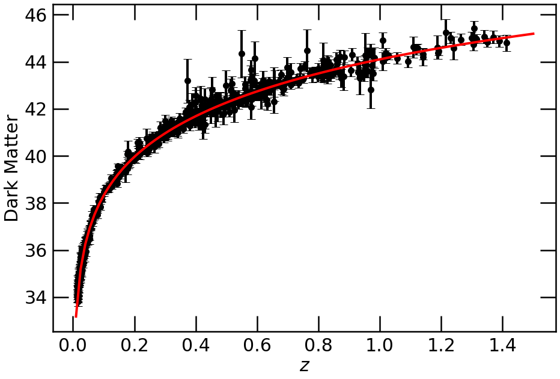

```python
from astropy.cosmology import LambdaCDM

# Function which determines the supernova luminosity distance for given cosmological parameters (Omega_m, Omega_L)
def get_darkmatter_model(Omega_m, Omega_L, z):  # initial data point: (Omega_m, Omega_L), redshift: z
    #om,ol = p[0],p[1]

    cosmo = LambdaCDM(H0=70.,Om0=Omega_m,Ode0=Omega_L)
    # Hubble constant = 70, Om0 dark matter, Ode0

    print('Lambda CDM model parameters :',cosmo)

    r = cosmo.comoving_distance(z).value
    print('comiving distance value',r)

    dl = r*(1.+z)    ## distance

    return 5.*np.log10(dl) + 25.   # equation (6) in the paper.


# Read in and plot the supernova dataset
# You will need to change the file path to the location where you've saved the data
#datfile = '../datasets/SN_dataset.dat'
datfile = direc+'/data/SN_dataset.dat'


data = np.loadtxt(datfile)
z,dm,dmerr = data[:,0],data[:,1],data[:,2]  # redshift: x, dark matter: dm, dark matter error: dmerr
#print('data size', len(z) )


## ===================== Plot data ======================
fig, ax = plt.subplots(figsize=(15, 10))
ax.plot(z,dm,marker='o',markersize=10,color='black',linestyle='None')
ax.errorbar(z,dm,yerr=dmerr,color='black',capsize=7.,linestyle='None')

# Overplot a standard cosmological model as an example
xmin,xmax = 0.,1.5
z_mod = np.linspace(0.01,xmax,100)   ## Redshift model

#p = [0.3,0.7] # values of (Omega_m, Omega_L)
Omega_m = 0.3
Omega_L = 0.7
dm_mod = get_darkmatter_model(Omega_m, Omega_L, z_mod)


ax.plot(z_mod,dm_mod,color='red')
ax.set_xlabel(r'$z$')
ax.set_ylabel(r'$\rm Dark \ Matter$')

plt.savefig('Chisquare_confident_region_DM_DE.png',dpi=300)
```

```python
LambdaCDM?
```

[output not shown]

[output cut: 11 more lines]

[output not shown]